# Analysis

## Motivation:

Some questions we wanted to answer through our analysis: Does government expenditure have a significant impact on general health? How much do these other factors affect health variables? Which of these predictors of health has the greatest impact on health? How do health trends change over time?

## Breadth of the Analysis:

[output not shown]

## Depth of the Analysis:

[output not shown]

## Modeling and Inference:

[output not shown]

```r
suppressPackageStartupMessages(library(tidyverse))
print(getwd())
```

```
## [1] "C:/Users/Shawn Xu/Desktop/MA415/ma4615-fa22-final-project-team-swej/content"
```

```r
MAPvsEx <- read_csv(here::here("dataset/MAPvsEx.csv"))
modelData <- read_csv(here::here("dataset/modelData.csv"))
# creating multiple linear regression model to predict MAP
model <- lm(MAP ~ factor(RIDRETH1) + factor(Year) + RIDAGEYR + factor(RIAGENDR), data = modelData)
summary(model)
```

```
##
## Call:
## lm(formula = MAP ~ factor(RIDRETH1) + factor(Year) + RIDAGEYR +
##     factor(RIAGENDR), data = modelData)
##
## Residuals:
##     Min      1Q  Median      3Q     Max
## -65.642  -6.711  -0.001   6.855  77.948
##
## Coefficients:
##                    Estimate Std. Error t value Pr(>|t|)
## (Intercept)       74.547671   0.175134 425.661  < 2e-16 ***
## factor(RIDRETH1)2  0.092609   0.185293   0.500  0.61722
## factor(RIDRETH1)3 -0.133073   0.121654  -1.094  0.27402
## factor(RIDRETH1)4  2.191404   0.133011  16.475  < 2e-16 ***
## factor(RIDRETH1)5  1.337547   0.179590   7.448 9.60e-14 ***
## factor(Year)2002  -0.792644   0.194631  -4.073 4.66e-05 ***
## factor(Year)2004  -1.958727   0.198752  -9.855  < 2e-16 ***
## factor(Year)2006  -2.042844   0.197630 -10.337  < 2e-16 ***
## factor(Year)2008  -1.894050   0.198109  -9.561  < 2e-16 ***
## factor(Year)2010  -2.935005   0.195022 -15.050  < 2e-16 ***
## factor(Year)2012  -2.115927   0.201580 -10.497  < 2e-16 ***
## factor(Year)2014  -2.785746   0.197615 -14.097  < 2e-16 ***
## factor(Year)2016  -1.786119   0.198890  -8.980  < 2e-16 ***
## factor(Year)2018  -0.668206   0.204425  -3.269  0.00108 **
## RIDAGEYR           0.299772   0.001994 150.358  < 2e-16 ***
## factor(RIAGENDR)2 -1.935095   0.087827 -22.033  < 2e-16 ***
## ---
## Signif. codes:  0 '***' 0.001 '**' 0.01 '*' 0.05 '.' 0.1 ' ' 1
##
## Residual standard error: 11.88 on 73264 degrees of freedom
## Multiple R-squared:  0.2498, Adjusted R-squared:  0.2497
## F-statistic:  1627 on 15 and 73264 DF,  p-value: < 2.2e-16
```

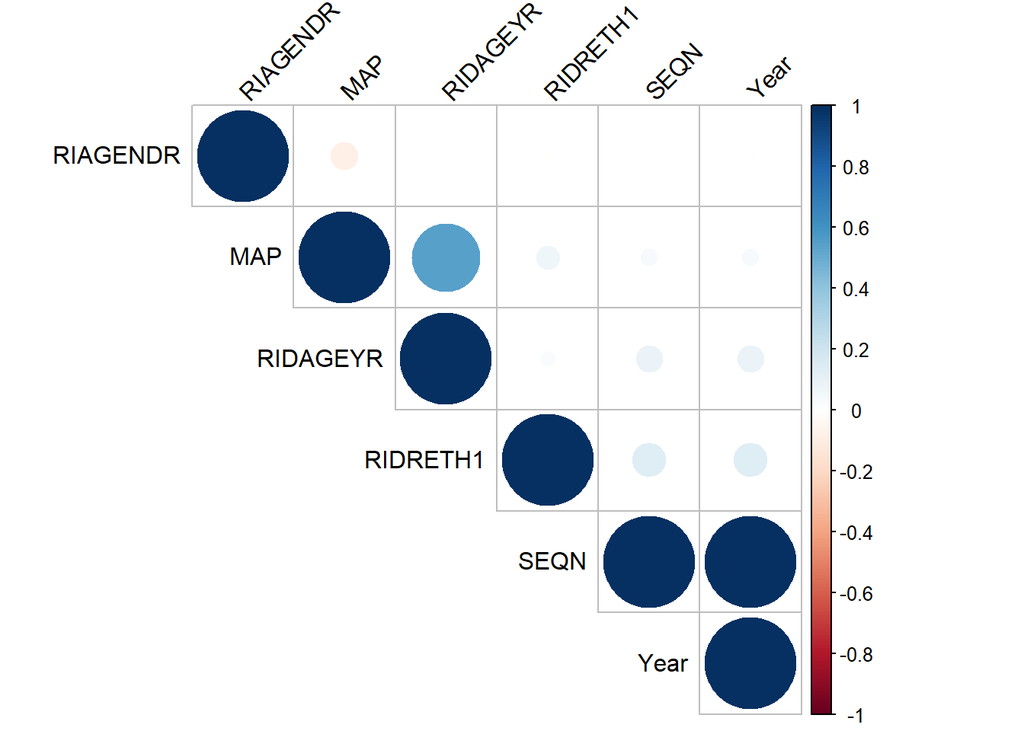

```r
library(corrplot)
model_cor <- cor(modelData, method = c("spearman"))
corrplot(model_cor, type = "upper", order = "hclust",
         tl.col = "black", tl.srt = 45)
```

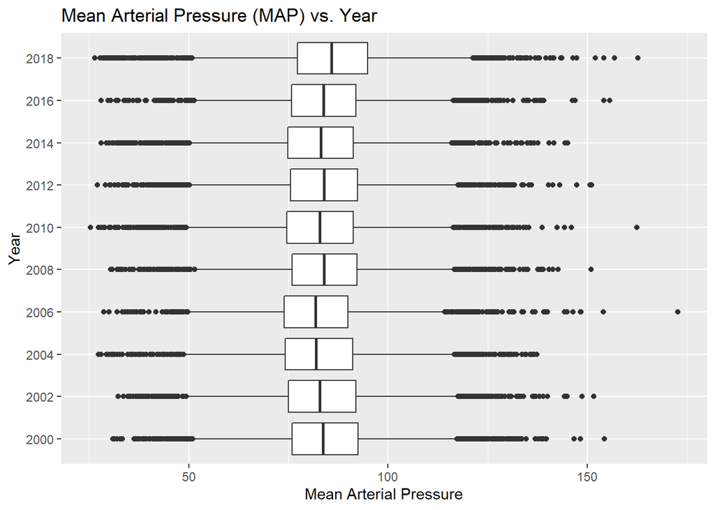

```r
modelData %>% ggplot(aes(x = factor(Year), y = MAP)) +
  geom_boxplot() +
  stat_smooth(method = "lm", se = FALSE) +
  labs(title = "Mean Arterial Pressure (MAP) vs. Year", x = "Year", y = "Mean Arterial Pressure") +
  coord_flip()
```

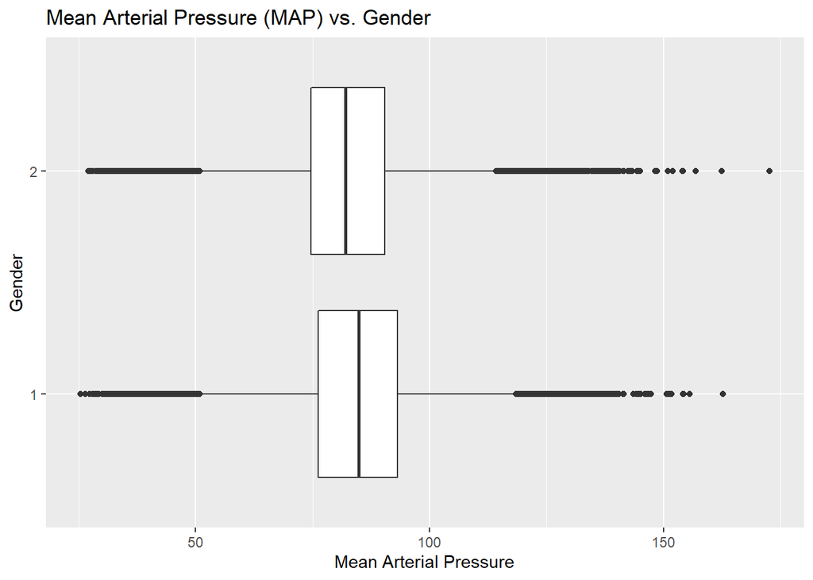

```r
modelData %>% ggplot(aes(x = factor(RIAGENDR), y = MAP)) +
  geom_boxplot() +
  stat_smooth(method = "lm", se = FALSE) +
  labs(title = "Mean Arterial Pressure (MAP) vs. Gender", x = "Gender", y = "Mean Arterial Pressure") +
  coord_flip()
```

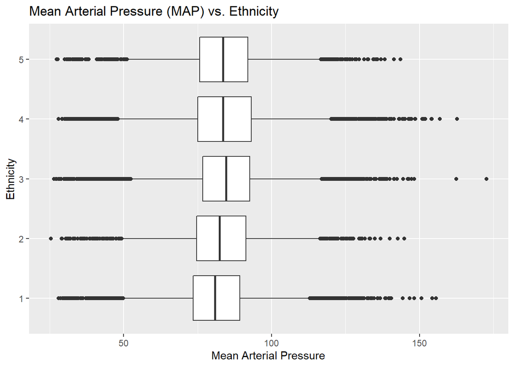

```r
modelData %>% ggplot(aes(x = factor(RIDRETH1), y = MAP)) +
  geom_boxplot() +
  stat_smooth(method = "lm", se = FALSE) +
  labs(title = "Mean Arterial Pressure (MAP) vs. Ethnicity",
       x = "Ethnicity", y = "Mean Arterial Pressure") +
  coord_flip()
```

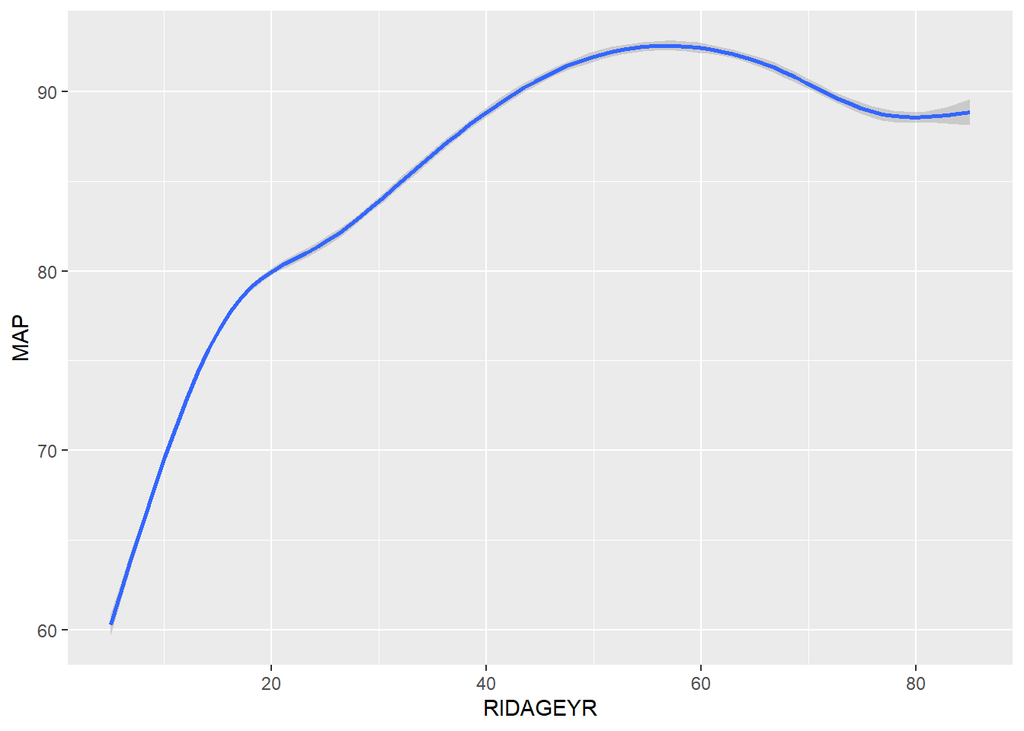

```r
age_plot <- ggplot(modelData, aes(x=RIDAGEYR, y=MAP)) +
  geom_smooth(method = "gam")
age_plot
```

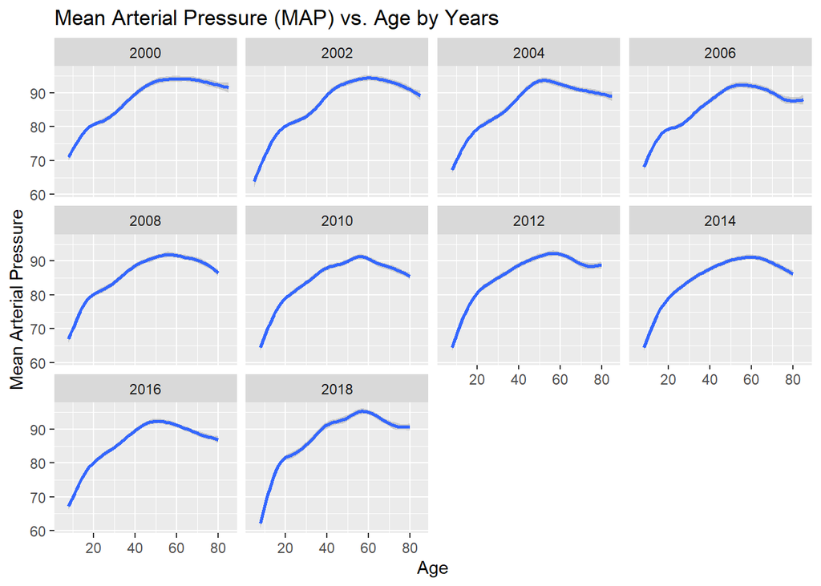

```r
year_facet <- age_plot + facet_wrap( ~ Year, ncol=4)+
  labs(title = "Mean Arterial Pressure (MAP) vs. Age by Years",
       x = "Age", y = "Mean Arterial Pressure")
year_facet
```

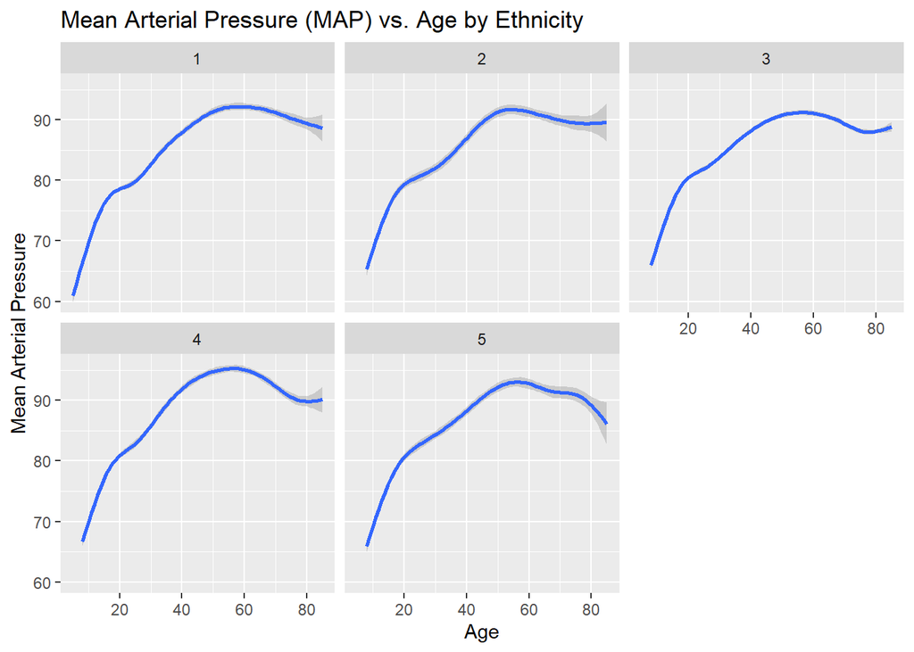

```r
ethnicity_facet <- age_plot + facet_wrap( ~ RIDRETH1) +
  labs(title = "Mean Arterial Pressure (MAP) vs. Age by Ethnicity",
       x = "Age", y = "Mean Arterial Pressure")
ethnicity_facet
```

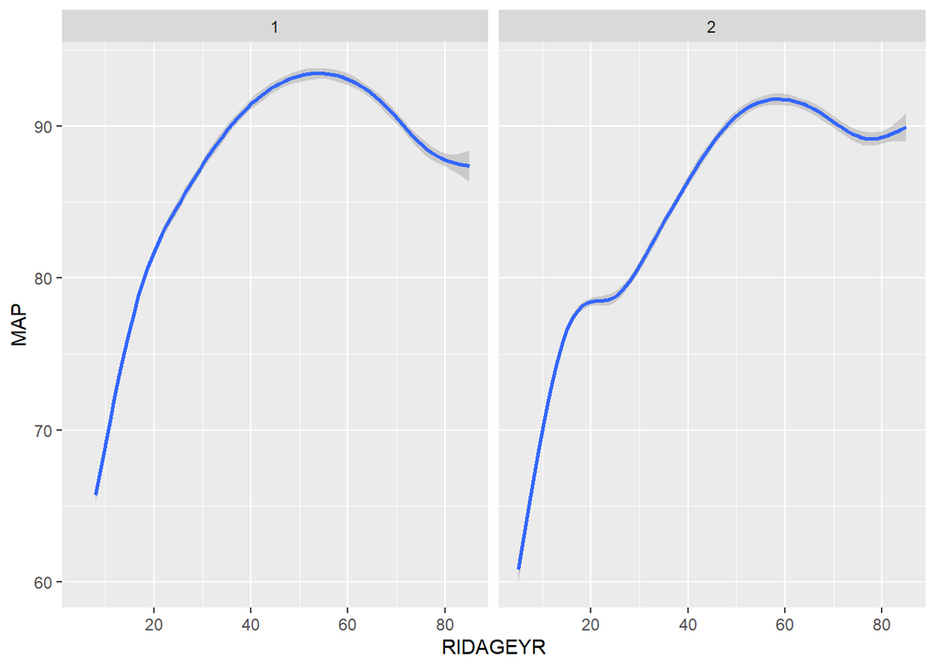

```r
gender_facet <- age_plot + facet_wrap( ~ RIAGENDR)
gender_facet
```

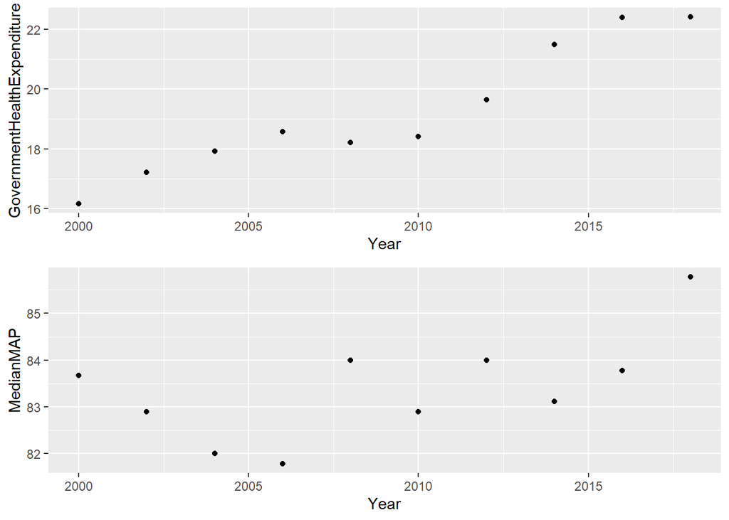

```r
plot_govExp <- ggplot(data = MAPvsEx,aes(x=Year, y = GovernmentHealthExpenditure)) +
         geom_point()
plot_medMAP <- ggplot(data = MAPvsEx,aes(x=Year, y = MedianMAP)) +
         geom_point()

library(grid)
grid.newpage()
grid.draw(rbind(ggplotGrob(plot_govExp), ggplotGrob(plot_medMAP), size = "last"))
```

```r
MAPEx_model <- lm(MedianMAP ~ GovernmentHealthExpenditure, data = MAPvsEx)
summary(MAPEx_model)
```

```
##
## Call:
## lm(formula = MedianMAP ~ GovernmentHealthExpenditure, data = MAPvsEx)
##
## Residuals:
##     Min      1Q  Median      3Q     Max
## -1.4337 -0.7629 -0.1232  0.7889  1.5544
##
## Coefficients:
##                             Estimate Std. Error t value Pr(>|t|)
## (Intercept)                  78.3139     3.1093  25.187 6.61e-09 ***
## GovernmentHealthExpenditure   0.2638     0.1607   1.642    0.139
## ---
## Signif. codes:  0 '***' 0.001 '**' 0.01 '*' 0.05 '.' 0.1 ' ' 1
##
## Residual standard error: 1.05 on 8 degrees of freedom
## Multiple R-squared:  0.252,  Adjusted R-squared:  0.1585
## F-statistic: 2.695 on 1 and 8 DF,  p-value: 0.1393
```

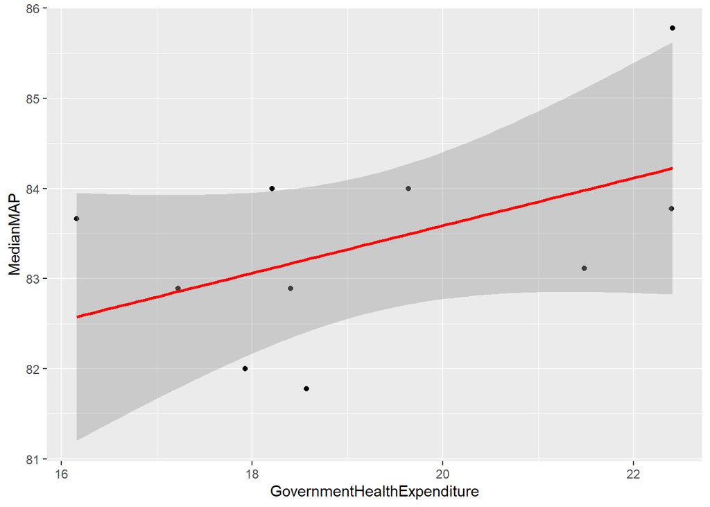

```r
ggplot(MAPvsEx, aes(x = GovernmentHealthExpenditure, y = MedianMAP)) +
  geom_point() +
  stat_smooth(method = "lm", col = "red")
```

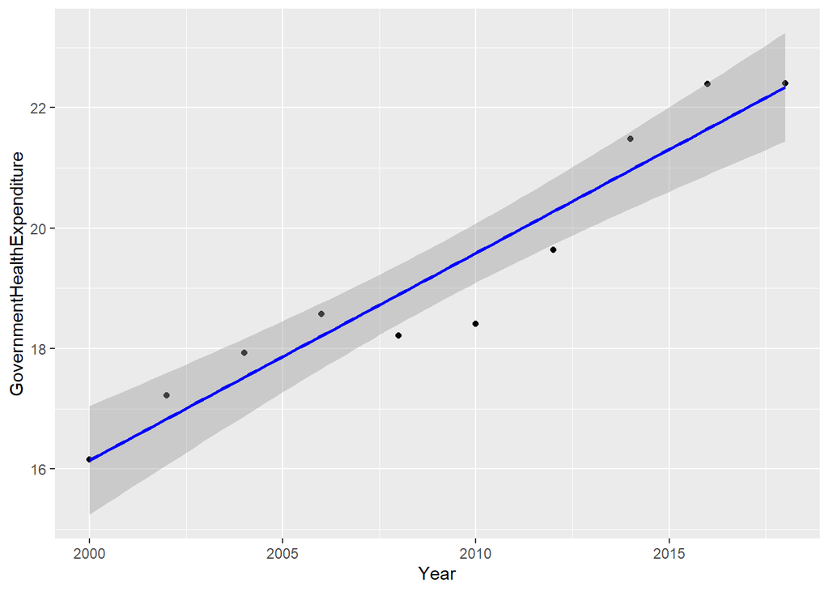

```r
ggplot(MAPvsEx, aes(x = Year, y = GovernmentHealthExpenditure)) +
  geom_point() +
  stat_smooth(method = "lm", col = "blue")
```

## Note on Attribution

If you are directly quoting from a source, please make that clear. You can show quotes using `>` like this

```
> To be or not to be.
```

> To be or not to be.

Also, make sure to provide a link or citation to where you are quoting from.

## Rubric: On this page

you will

- Introduce what motivates your Data Analysis (DA)
  - Which variables and relationships are you most interested in?
  - What questions are you interested in answering?
- Breadth of the DA
  - Make sure that you ask enough initial questions to explore the different variables in your data.
  - i.e. Do you explore more than just one or two variables? Do you explore a few different relationships or many?
- Depth of the DA
  - When you answer one question, usually more questions arise as well.
  - The depth of the DA is about coming up with and exploring the answers to these questions, often iterating the process a few times.
- Modeling and Inference
  - You should also include some kind of formal statistical model and/or inference. This could be a linear regression, logistic regression, hypothesis testing etc.
  - Explain the techniques you used for validating your results.
  - Describe the results of your modelling and make sure to give a sense of the uncertainty in your estimates and conclusions.
- Explain the flaws and limitations of your analysis
  - Are there some assumptions that you needed to make that might not hold? Is there other data that would help to answer your questions? …
- Clarity Figures
  - Are your figures/tables/results easy to read, informative, without problems like overplotting, hard-to-read labels, etc?
  - Each figure should provide a key insight. Too many figures or other data summaries can detract from this.
- Clarity of Explanations
  - Do you introduce why you are doing each analysis?
  - How well do you explain each figure/result?
  - Do you provide interpretations that suggest further analysis or explanations for observed phenomenon?
- Organization and cleanliness.
  - Make sure to remove excessive warnings, use clean easy-to-read code, organize with sections or multiple pages, use bullets, etc.

**NOTE**: Your Data Analysis can be broken up into multiple pages if that helps with your organization.